# 02_c_data_source_difference

Claire Moore

7/19/2021

This script is designed to highlight the differences in the data sources before merging.

*Advice sheet* Raised total of catchs, landings and discards for 2019, taken form advice sheet

```r
advice_key <- icesSAG::findAssessmentKey( stock = stock_list, year = 2020,  published = TRUE)
```

```
## GETing ... http://sg.ices.dk/StandardGraphsWebServices.asmx/getListStocks?year=2020
```

```r
advice_sheet <- icesSAG::getSummaryTable(advice_key)
```

```
## GETing ... http://sg.ices.dk/StandardGraphsWebServices.asmx/getSummaryTable?assessmentKey=14014
```

```
## GETing ... http://sg.ices.dk/StandardGraphsWebServices.asmx/getSummaryTable?assessmentKey=13978
```

```
## GETing ... http://sg.ices.dk/StandardGraphsWebServices.asmx/getSummaryTable?assessmentKey=13993
```

```
## GETing ... http://sg.ices.dk/StandardGraphsWebServices.asmx/getSummaryTable?assessmentKey=13755
```

```
## GETing ... http://sg.ices.dk/StandardGraphsWebServices.asmx/getSummaryTable?assessmentKey=13602
```

```
## GETing ... http://sg.ices.dk/StandardGraphsWebServices.asmx/getSummaryTable?assessmentKey=13867
```

```
## GETing ... http://sg.ices.dk/StandardGraphsWebServices.asmx/getSummaryTable?assessmentKey=14565
```

```r
cod_advice <- as.data.frame(advice_sheet[1]) %>% select(fishstock, Year, stockSizeUnits, landings, discards, catches) %>%gather(catch_cat, total, 4:6)

had_advice <- as.data.frame(advice_sheet[2]) %>% select(fishstock, Year, stockSizeUnits, landings, discards, catches) %>%gather(catch_cat, total, 4:6)

whg_advice <- as.data.frame(advice_sheet[3]) %>% select(fishstock, Year, stockSizeUnits, landings, discards, catches) %>%gather(catch_cat, total, 4:6)

sol_advice <- as.data.frame(advice_sheet[4]) %>% select(fishstock, Year, stockSizeUnits, landings, discards, catches) %>%gather(catch_cat, total, 4:6)

meg_advice <- as.data.frame(advice_sheet[5]) %>% select(fishstock, Year, stockSizeUnits, landings, discards, catches) %>%gather(catch_cat, total, 4:6)

mon_advice <- as.data.frame(advice_sheet[6]) %>% select(fishstock, Year, stockSizeUnits, landings, discards, catches) %>%gather(catch_cat, total, 4:6)

hke_advice <- as.data.frame(advice_sheet[7]) %>% select(fishstock, Year, stockSizeUnits, landings, discards, catches) %>%gather(catch_cat, total, 4:6)

advice_sheet_values <- rbind(cod_advice, had_advice, whg_advice, sol_advice, meg_advice, mon_advice, hke_advice)

advice_sheet_values$source <- "advice sheet"
advice_sheet_values$catch_cat[advice_sheet_values$catch_cat == "catches"] <- "catch"


advice_sheet_values <- advice_sheet_values %>% select(Year, fishstock, source, stockSizeUnits,  catch_cat, total)

names(advice_sheet_values) <- c("year", "stock", "source",  "unit","catch_cat", "total")
```

*Stock objects* Raised total of catchs, landings and discards for 2019, taken from stock objects supplied by single species stock coordinator and formatted by WGMIXFISH

```r
stock_object_summary <- data.frame("year" = NaN, "catch_cat" = NaN, "total" = NaN,  "unit" = NaN, "stock" = NaN)

#i = "cod.27.7e-k"
for(i in stock_list){
print(i)
load(paste0("results/clean_data/clean_stock_objects/", i ,".RData"))

landings_info <- as.data.frame(stock@landings@.Data)
names(landings_info) <- substr(names(landings_info),1,4)
landings_info <- gather(landings_info, year, total)
landings_info$catch_cat <- "landings"
landings_info$unit <- NaN
landings_info$stock <- paste(i)

discards_info <- as.data.frame(stock@discards@.Data)
names(discards_info) <- substr(names(discards_info),1,4)
discards_info <- gather(discards_info, year, total)
discards_info$catch_cat <- "discards"
discards_info$unit <- NaN
discards_info$stock <- paste(i)

catch_info <- as.data.frame(stock@catch@.Data)
names(catch_info) <- substr(names(catch_info),1,4)
catch_info <- gather(catch_info, year, total)
catch_info$catch_cat <- "catch"
catch_info$unit <- NaN
catch_info$stock <- paste(i)

object_summary <- rbind(landings_info,discards_info, catch_info)
stock_object_summary <- rbind(stock_object_summary, object_summary)
rm(stock,object_summary)
}
```

```
## [1] "cod.27.7e-k"
## [1] "had.27.7b-k"
## [1] "whg.27.7b-ce-k"
## [1] "sol.27.7fg"
## [1] "meg.27.7b-k8abd"
## [1] "mon.27.78abd"
## [1] "hke.27.3a46-8abd"
```

```r
stock_object_summary <- stock_object_summary [!stock_object_summary$stock == NaN,]
stock_object_summary$source <-  "stock object"

stock_object_summary <-stock_object_summary %>% select(year, stock, source, unit, catch_cat,  total)
```

*InterCatch CATON*

```r
inter_caton <- read.csv("results/clean_data/caton_summary.csv")
inter_caton$source <- "intercatch caton"
inter_caton$unit <- NaN
inter_caton <- inter_caton %>% select(Year, Stock, source, unit, Landings, Discards)%>% mutate("catch" = Landings+Discards) %>% gather(catch_cat, total, 5:7) %>% group_by(Year, Stock, source, unit, catch_cat) %>% summarise(total = sum(total, na.rm=T)) %>% data.frame()
names(inter_caton) <- c("year", "stock", "source", "unit" ,"catch_cat", "total" )
```

*InterCatch CANUM*

```r
inter_canum <- read.csv("results/clean_data/canum_summary.csv")
inter_canum$source <- "intercatch canum"
inter_canum$unit <- NaN

inter_canum <- inter_canum %>% select(Year, Stock, source, unit, CatchCat, samples_weight_kg) %>% group_by(Year, Stock, source, unit, CatchCat) %>% summarise(total = sum(samples_weight_kg, na.rm=T)) %>% data.frame()
inter_canum <- inter_canum %>% tidyr::spread(CatchCat, total) %>% mutate("catch" = Landings+Discards) %>% gather(catch_cat, total, 5:7) %>% group_by(Year, Stock, source, unit, catch_cat) %>% summarise(total = sum(total, na.rm=T)) %>% data.frame()
names(inter_canum) <- c("year", "stock", "source", "unit" ,"catch_cat", "total" )
```

Summary plots

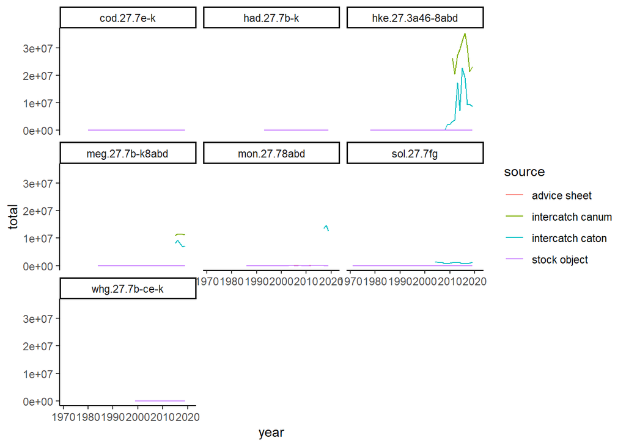

```r
all_dat <- rbind(inter_canum, inter_caton, stock_object_summary, advice_sheet_values)
all_dat$catch_cat <- tolower(all_dat$catch_cat)
all_dat$year <- as.numeric(all_dat$year)
all_dat <- all_dat[all_dat$stock %in% stock_list,]

ggplot(all_dat[all_dat$catch_cat == "catch",], aes(year, total, colour = source)) + geom_line() +facet_wrap(~stock) + theme_classic()
```

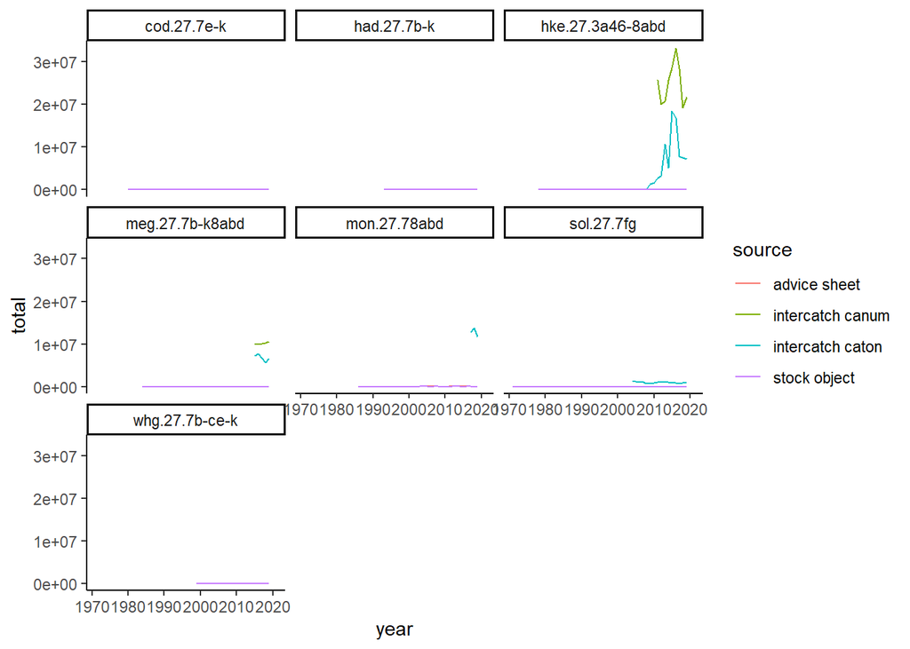

```r
ggplot(all_dat[all_dat$catch_cat == "landings",], aes(year, total, colour = source)) + geom_line() +facet_wrap(~stock) + theme_classic()
```

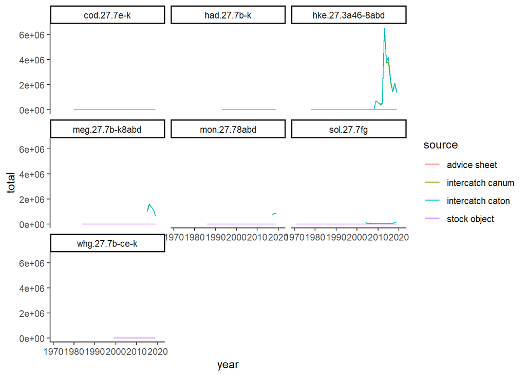

```r
ggplot(all_dat[all_dat$catch_cat == "discards",], aes(year, total, colour = source)) + geom_line() +facet_wrap(~stock) + theme_classic()
```

There is clearly a units issue here, so now we take it stock by stock and figure out if we can apply a blanket change or we need something more specfic to stocks and years.

Do the totals of of intercatch caton and canum match? Do these total match that displayed in the adviec sheet?

All data should be in tonnes.

For COD all sources in recent years. Historical differences are due to the absence of discards data.

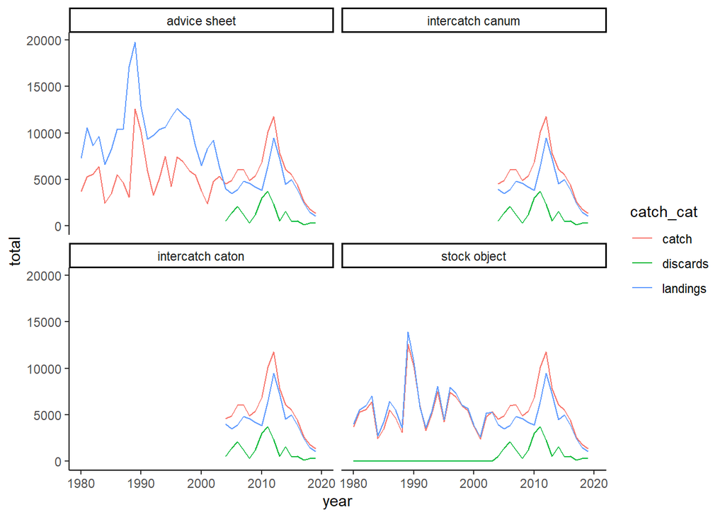

```r
ggplot(all_dat[all_dat$stock == "cod.27.7e-k",], aes(year, total, colour = catch_cat)) + geom_line() +facet_wrap(~source) + theme_classic()
```

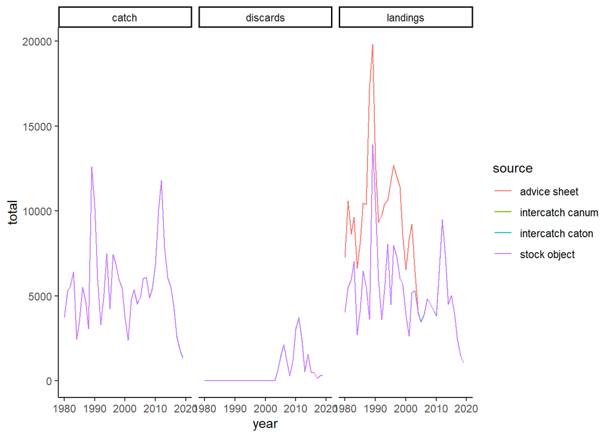

```r
ggplot(all_dat[all_dat$stock == "cod.27.7e-k",], aes(year, total, colour = source)) + geom_line() +facet_wrap(~catch_cat) + theme_classic()
```

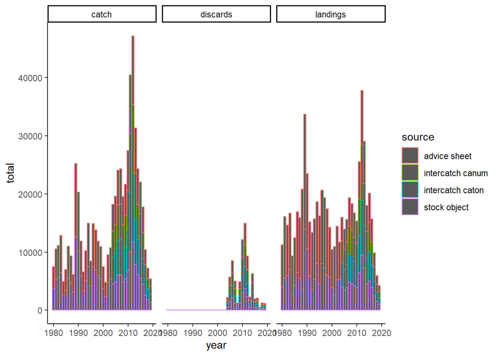

```r
ggplot(all_dat[all_dat$stock == "cod.27.7e-k",], aes(year, total, colour = source)) + geom_bar(stat="identity") +facet_wrap(~catch_cat) + theme_classic()
```

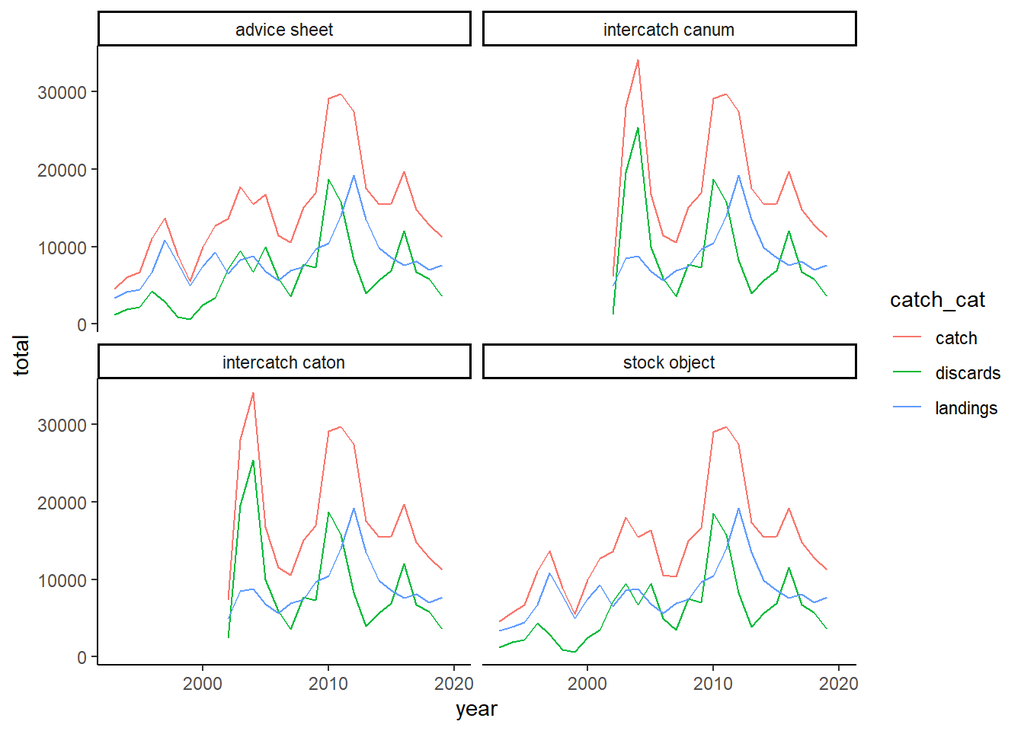

```r
ggplot(all_dat[all_dat$stock == "had.27.7b-k" ,], aes(year, total, colour = catch_cat)) + geom_line() +facet_wrap(~source) + theme_classic()
```

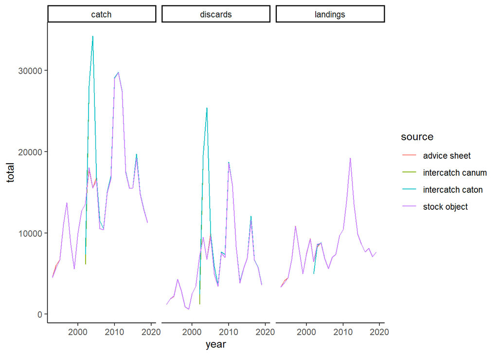

```r
ggplot(all_dat[all_dat$stock == "had.27.7b-k" ,], aes(year, total, colour = source)) + geom_line() +facet_wrap(~catch_cat) + theme_classic()
```

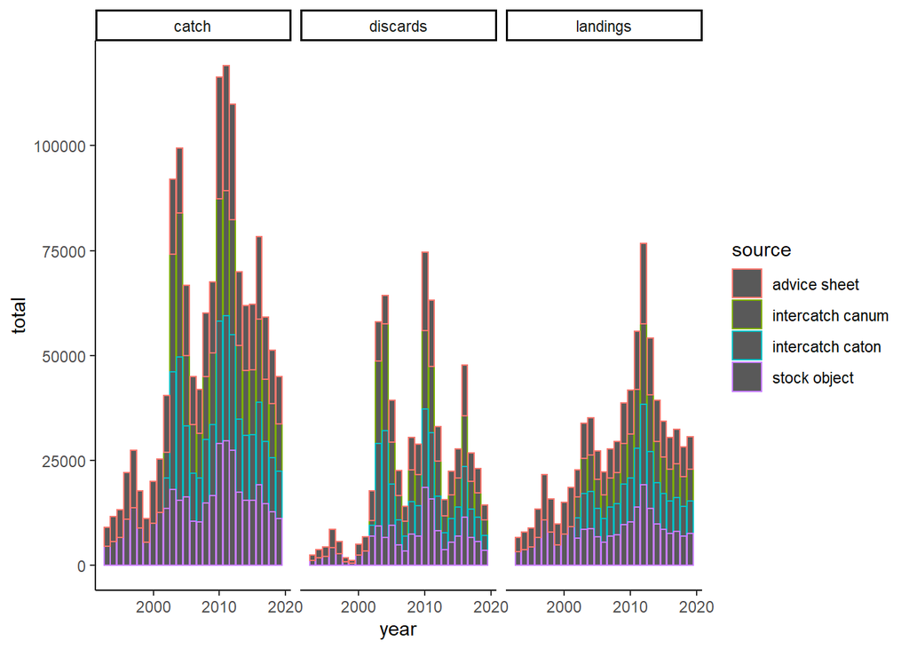

```r
ggplot(all_dat[all_dat$stock == "had.27.7b-k" ,], aes(year, total, colour = source)) + geom_bar(stat="identity") +facet_wrap(~catch_cat) + theme_classic()
```

For whg some differences but mostly ok for the last 3 years so I think we are ok.

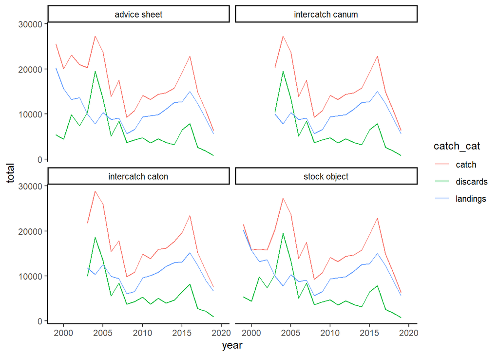

```r
ggplot(all_dat[all_dat$stock == "whg.27.7b-ce-k" ,], aes(year, total, colour = catch_cat)) + geom_line() +facet_wrap(~source) + theme_classic()
```

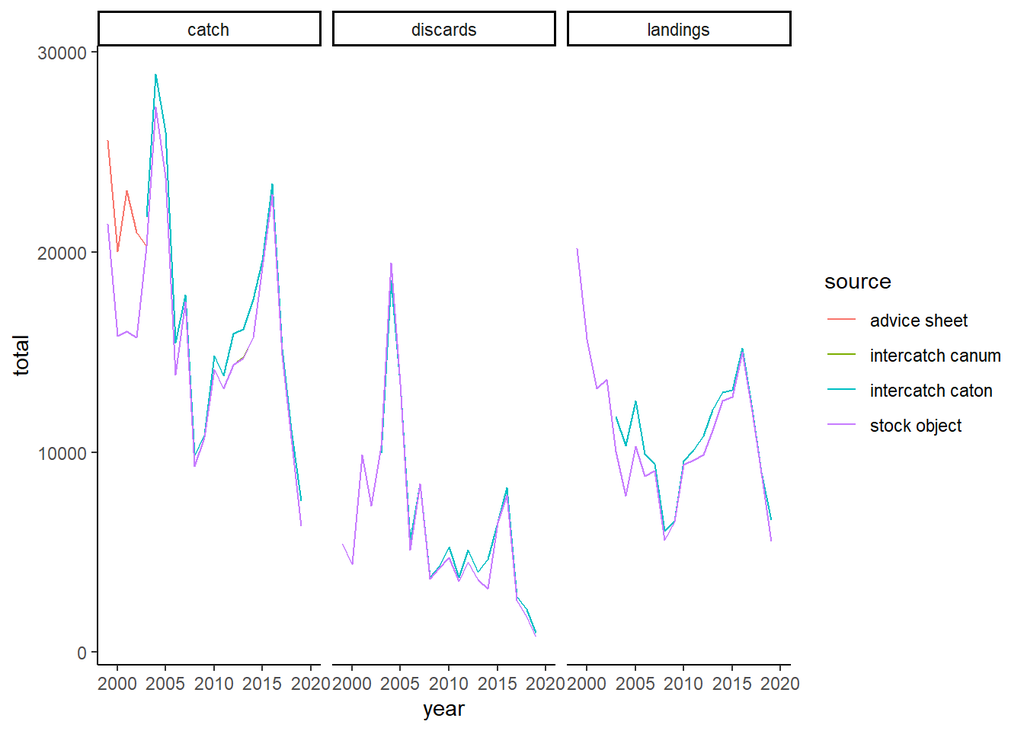

```r
ggplot(all_dat[all_dat$stock == "whg.27.7b-ce-k" ,], aes(year, total, colour = source)) + geom_line() +facet_wrap(~catch_cat) + theme_classic()
```

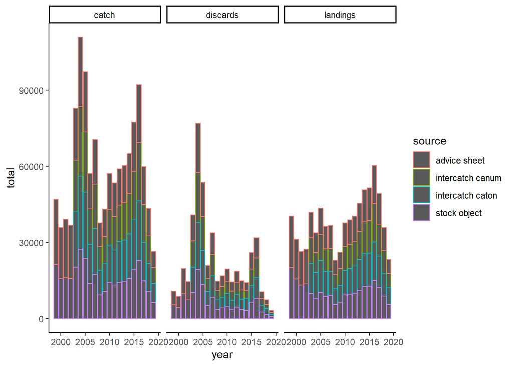

```r
ggplot(all_dat[all_dat$stock == "whg.27.7b-ce-k" ,], aes(year, total, colour = source)) + geom_bar(stat="identity") +facet_wrap(~catch_cat) + theme_classic()
```

For mon nothing matches!!!

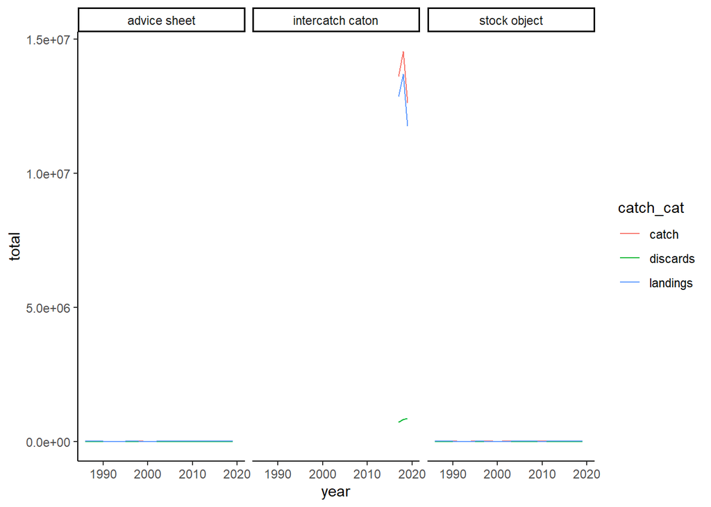

```r
ggplot(all_dat[all_dat$stock == "mon.27.78abd" ,], aes(year, total, colour = catch_cat)) + geom_line() +facet_wrap(~source) + theme_classic()
```

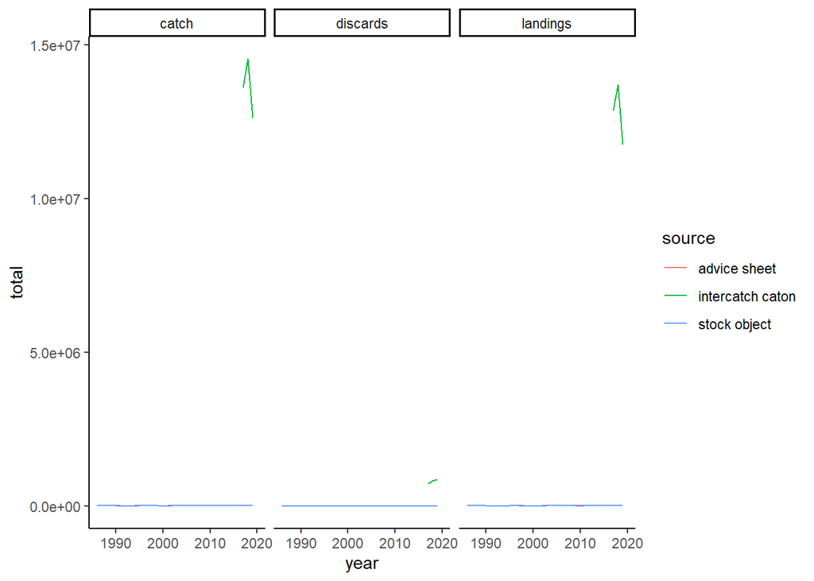

```r
ggplot(all_dat[all_dat$stock == "mon.27.78abd" ,], aes(year, total, colour = source)) + geom_line() +facet_wrap(~catch_cat) + theme_classic()
```

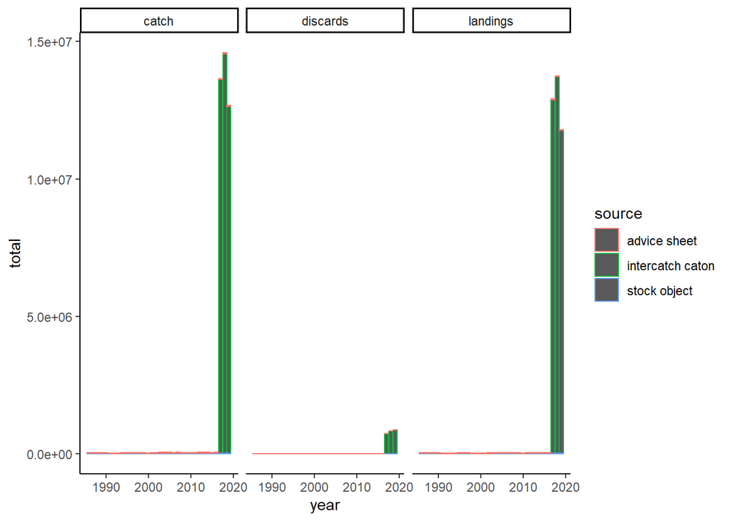

```r
ggplot(all_dat[all_dat$stock == "mon.27.78abd" ,], aes(year, total, colour = source)) + geom_bar(stat="identity") +facet_wrap(~catch_cat) + theme_classic()
```

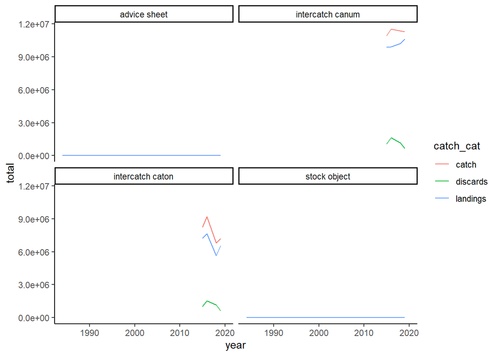

```r
ggplot(all_dat[all_dat$stock == "meg.27.7b-k8abd"  ,], aes(year, total, colour = catch_cat)) + geom_line() +facet_wrap(~source) + theme_classic()
```

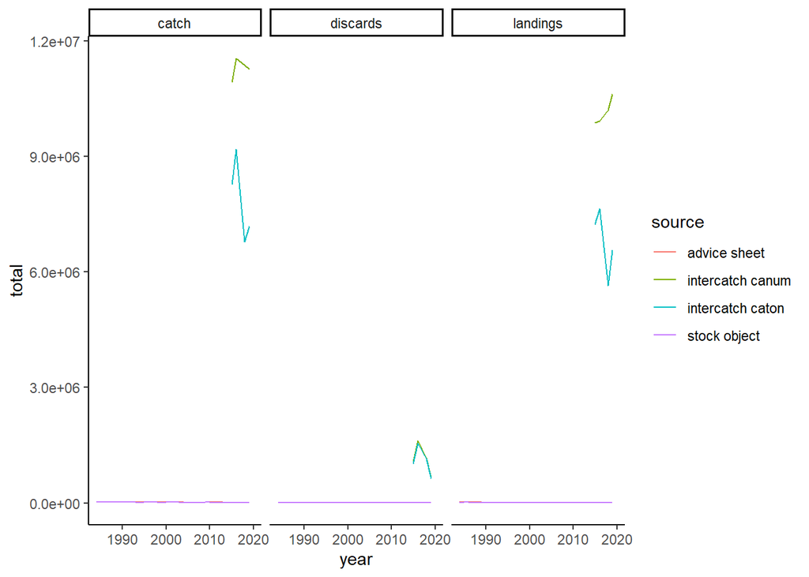

```r
ggplot(all_dat[all_dat$stock == "meg.27.7b-k8abd"  ,], aes(year, total, colour = source)) + geom_line() +facet_wrap(~catch_cat) + theme_classic()
```

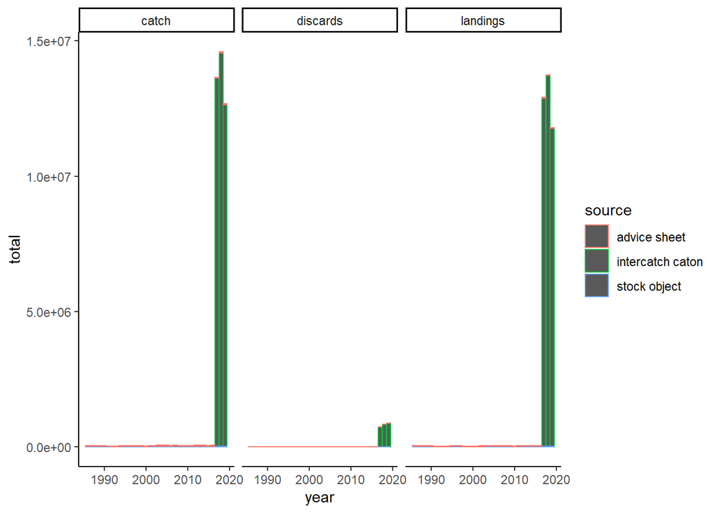

```r
ggplot(all_dat[all_dat$stock == "mon.27.78abd" ,], aes(year, total, colour = source)) + geom_bar(stat="identity") +facet_wrap(~catch_cat) + theme_classic()
```

For HKE- units area in kg in intercatch and tonnes in advice sheet at stock object. But the landings in the canum are much higher then Caton.

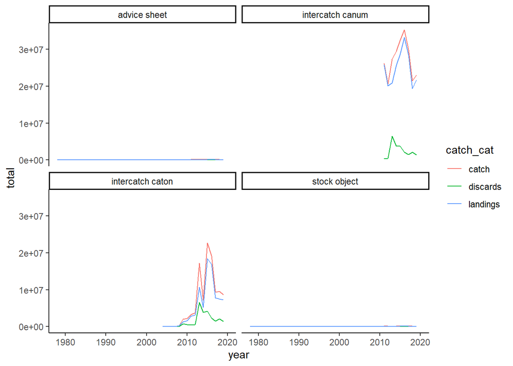

```r
ggplot(all_dat[all_dat$stock == "hke.27.3a46-8abd"  ,], aes(year, total, colour = catch_cat)) + geom_line() +facet_wrap(~source) + theme_classic()
```

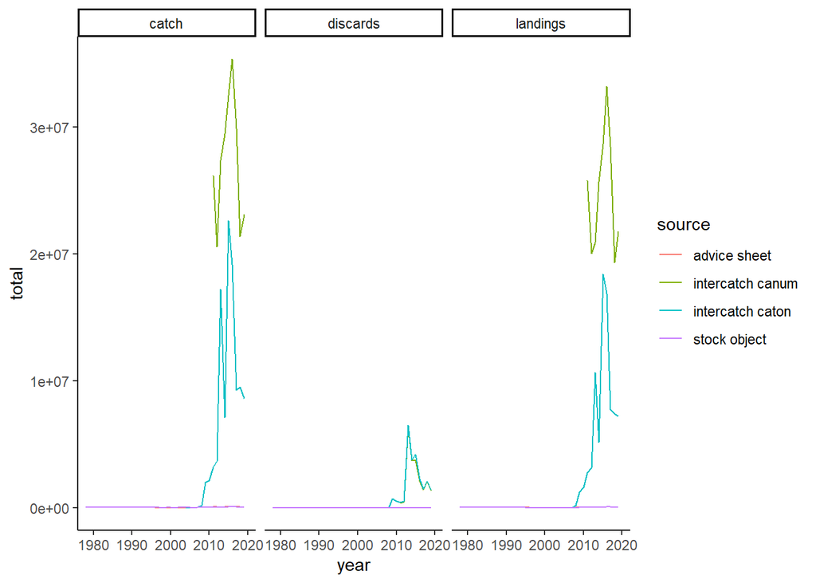

```r
ggplot(all_dat[all_dat$stock == "hke.27.3a46-8abd"  ,], aes(year, total, colour = source)) + geom_line() +facet_wrap(~catch_cat) + theme_classic()
```

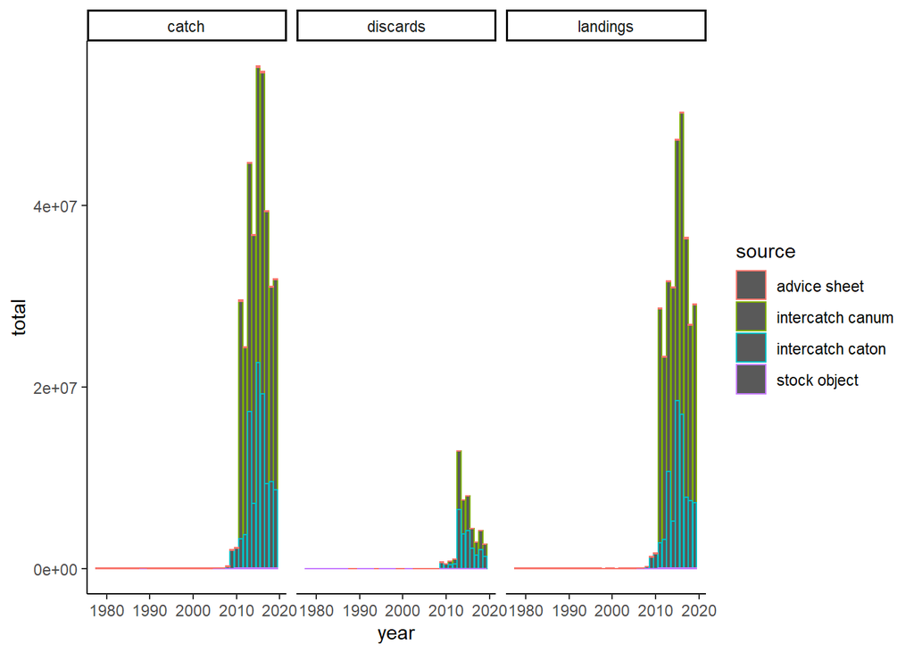

```r
ggplot(all_dat[all_dat$stock == "hke.27.3a46-8abd" ,], aes(year, total, colour = source)) + geom_bar(stat="identity") +facet_wrap(~catch_cat) + theme_classic()
```

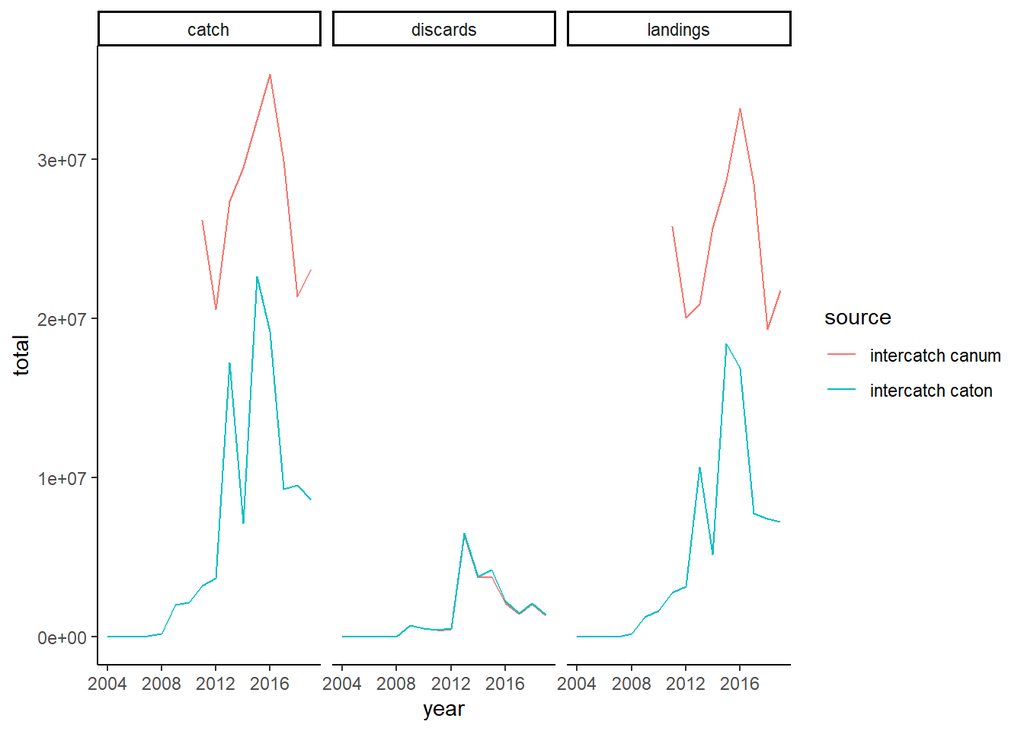

```r
newdat_hke <- all_dat[all_dat$stock == "hke.27.3a46-8abd" & all_dat$source %in% c("intercatch canum", "intercatch caton"),]
ggplot(newdat_hke, aes(year, total, colour = source)) + geom_line() +facet_wrap(~catch_cat) + theme_classic()
```

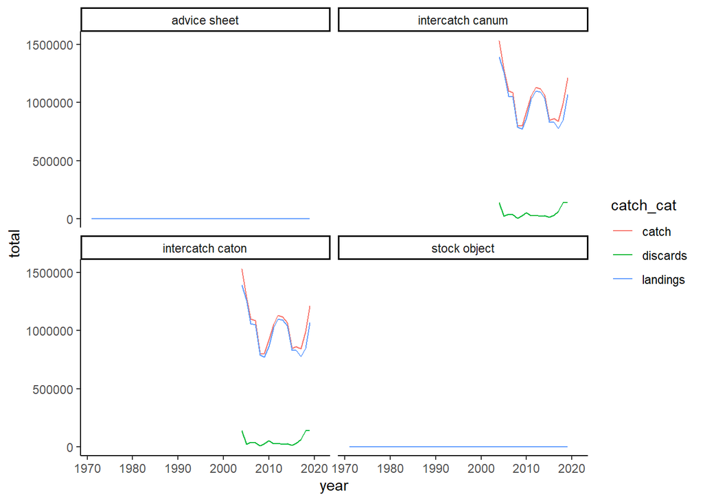

```r
ggplot(all_dat[all_dat$stock == "sol.27.7fg",], aes(year, total, colour = catch_cat)) + geom_line() +facet_wrap(~source) + theme_classic()
```

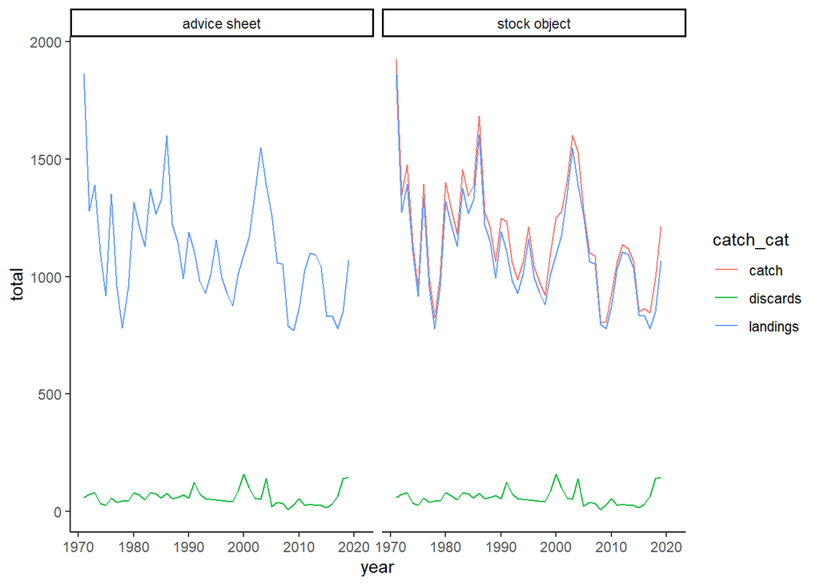

```r
ggplot(all_dat[all_dat$stock == "sol.27.7fg" & all_dat$source %in% c("advice sheet", "stock object"),], aes(year, total, colour = catch_cat)) + geom_line() +facet_wrap(~source) + theme_classic()
```

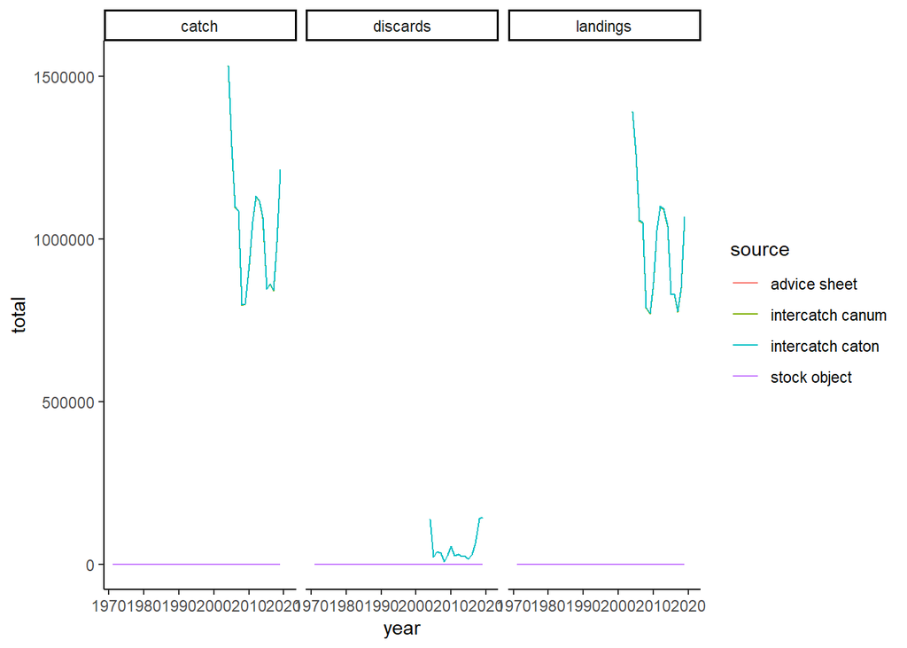

```r
ggplot(all_dat[all_dat$stock == "sol.27.7fg"  ,], aes(year, total, colour = source)) + geom_line() +facet_wrap(~catch_cat) + theme_classic()
```